# Introduction to R

Erin Shellman

April 6, 2015

## Preparation

Exploratory data analysis is a crucial first step of any task involving data, and it’s a perfect way to get acquainted with our tools. This notebook is a guide for helping you get started using R. Does this notebook give you every detail you need to run your analyses in R? No, it is incomplete, but I will try to introduce new concepts and functions only as they become needed. For those who are new to R, new to working with data, new to programming, or all three please keep in mind:

> Whenever you’re learning a new tool, for a long time you’re going to suck… But the good news is that is typical, that’s something that happens to everyone, and it’s only temporary.

That’s advice [from Hadley Wickham](http://www.r-bloggers.com/hadley-wickhams-dplyr-tutorial-at-user-2014-part-1/), a statistician and software developer who has revolutionized the way that people use R. We’re going to use a lot of his software in this class.

#### Loading libraries

One of the greatest strengths of R is the active community. We’re going to use a handful of packages (or libraries) in this class. Today we’ll learn about two, `dplyr` and `ggplot2`.

```r
# Install the packages if you don't have them already.
# install.packages('dplyr')
# install.packages('ggplot2')

# Then load them up.
library(dplyr)
library(ggplot2)
```

#### Loading data

To start getting acquainted, we’ll use on of R’s many [preloaded datasets](http://stat.ethz.ch/R-manual/R-devel/library/datasets/html/00Index.html) called `swiss`. Loading it up for use is super simple.

```r
data(swiss)
```

Most of the time you won’t be using R’s built-in data sets, you want to work with your own! There are lots of ways to load data into R, but in this class you can get away with just this:

```r
# Set you working directory, which is normally where you data are.
setwd('path/to/your/data')
data = read.delim('data.txt',
                  header = TRUE,
                  sep = '\t')
```

Type `?read.delim` to learn what the `header` and `sep` arguments do.

Once data are loaded, there are tons of ways to spot-check it.

```r
dim(swiss) # print dimensions
```

```
## [1] 47  6
```

```r
names(swiss)
```

```
## [1] "Fertility"        "Agriculture"      "Examination"
## [4] "Education"        "Catholic"         "Infant.Mortality"
```

```r
str(swiss)
```

```
## 'data.frame':    47 obs. of  6 variables:
##  $ Fertility       : num  80.2 83.1 92.5 85.8 76.9 76.1 83.8 92.4 82.4 82.9 ...
##  $ Agriculture     : num  17 45.1 39.7 36.5 43.5 35.3 70.2 67.8 53.3 45.2 ...
##  $ Examination     : int  15 6 5 12 17 9 16 14 12 16 ...
##  $ Education       : int  12 9 5 7 15 7 7 8 7 13 ...
##  $ Catholic        : num  9.96 84.84 93.4 33.77 5.16 ...
##  $ Infant.Mortality: num  22.2 22.2 20.2 20.3 20.6 26.6 23.6 24.9 21 24.4 ...
```

```r
head(swiss, 3)
```

```
##              Fertility Agriculture Examination Education Catholic
## Courtelary        80.2        17.0          15        12     9.96
## Delemont          83.1        45.1           6         9    84.84
## Franches-Mnt      92.5        39.7           5         5    93.40
##              Infant.Mortality
## Courtelary               22.2
## Delemont                 22.2
## Franches-Mnt             20.2
```

```r
tail(swiss, 3)
```

```
##              Fertility Agriculture Examination Education Catholic
## V. De Geneve      35.0         1.2          37        53    42.34
## Rive Droite       44.7        46.6          16        29    50.43
## Rive Gauche       42.8        27.7          22        29    58.33
##              Infant.Mortality
## V. De Geneve             18.0
## Rive Droite              18.2
## Rive Gauche              19.3
```

```r
summary(swiss)
```

```
##    Fertility      Agriculture     Examination      Education
##  Min.   :35.00   Min.   : 1.20   Min.   : 3.00   Min.   : 1.00
##  1st Qu.:64.70   1st Qu.:35.90   1st Qu.:12.00   1st Qu.: 6.00
##  Median :70.40   Median :54.10   Median :16.00   Median : 8.00
##  Mean   :70.14   Mean   :50.66   Mean   :16.49   Mean   :10.98
##  3rd Qu.:78.45   3rd Qu.:67.65   3rd Qu.:22.00   3rd Qu.:12.00
##  Max.   :92.50   Max.   :89.70   Max.   :37.00   Max.   :53.00
##     Catholic       Infant.Mortality
##  Min.   :  2.150   Min.   :10.80
##  1st Qu.:  5.195   1st Qu.:18.15
##  Median : 15.140   Median :20.00
##  Mean   : 41.144   Mean   :19.94
##  3rd Qu.: 93.125   3rd Qu.:21.70
##  Max.   :100.000   Max.   :26.60
```

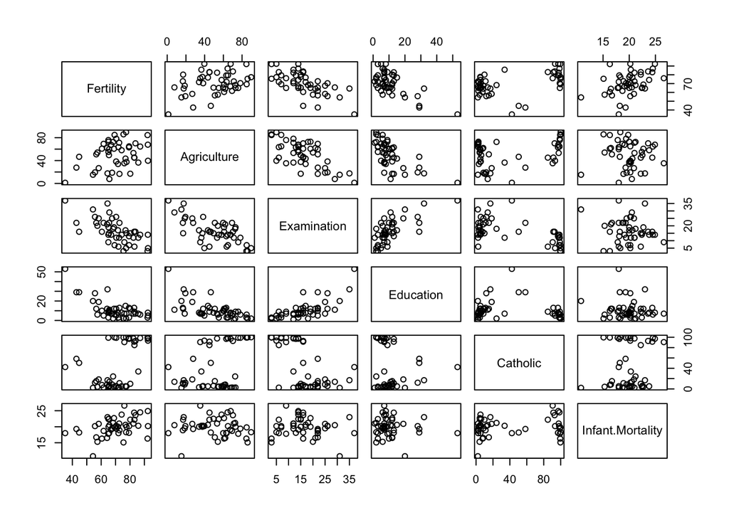

```r
plot(swiss)
```